# Google Case Study #1

Chris Fields

2022-11-06

```r
library(tidyverse)
library(lubridate)
```

# Cyclistic Bike Share Analysis

#### Question to be answered:

- What are the differences in Cyclistic bike usage between annual members and casual riders?
  - How could stakeholders use this information to convert casual riders into annual members?

The data used for this case study was generated by Divvy, a bicycle sharing service owned by the City of Chicago and operated by Lyft Bikes & Scooters, LLC.

This data has been made available for use by Motivate International Inc.

- [License for Use](https://ride.divvybikes.com/data-license-agreement)
- [Data Source](https://divvy-tripdata.s3.amazonaws.com/index.html)

#### Cleaning and Preparation of Data:

The most current data available is provided on a monthly basis, stored as comma- separated values.

**Step #1:** Import the data for analysis.

```r
cyclistic_oct_21 <- read.csv("csv_data/202110-divvy-tripdata.csv")
cyclistic_nov_21 <- read.csv("csv_data/202111-divvy-tripdata.csv")
cyclistic_dec_21 <- read.csv("csv_data/202112-divvy-tripdata.csv")
cyclistic_jan_22 <- read.csv("csv_data/202201-divvy-tripdata.csv")
cyclistic_feb_22 <- read.csv("csv_data/202202-divvy-tripdata.csv")
cyclistic_mar_22 <- read.csv("csv_data/202203-divvy-tripdata.csv")
cyclistic_apr_22 <- read.csv("csv_data/202204-divvy-tripdata.csv")
cyclistic_may_22 <- read.csv("csv_data/202205-divvy-tripdata.csv")
cyclistic_jun_22 <- read.csv("csv_data/202206-divvy-tripdata.csv")
cyclistic_jul_22 <- read.csv("csv_data/202207-divvy-tripdata.csv")
cyclistic_aug_22 <- read.csv("csv_data/202208-divvy-tripdata.csv")
cyclistic_sep_22 <- read.csv("csv_data/202209-divvy-publictripdata.csv")
```

**Step #2:** Compare the structure of the first two data sets to identify any differences between column names or data types.

```r
str(cyclistic_oct_21)
```

```
## 'data.frame':    631226 obs. of  13 variables:
##  $ ride_id           : chr  "620BC6107255BF4C" "4471C70731AB2E45" "26CA69D43D15EE14" "362947F0437E1514" ...
##  $ rideable_type     : chr  "electric_bike" "electric_bike" "electric_bike" "electric_bike" ...
##  $ started_at        : chr  "2021-10-22 12:46:42" "2021-10-21 09:12:37" "2021-10-16 16:28:39" "2021-10-16 16:17:48" ...
##  $ ended_at          : chr  "2021-10-22 12:49:50" "2021-10-21 09:14:14" "2021-10-16 16:36:26" "2021-10-16 16:19:03" ...
##  $ start_station_name: chr  "Kingsbury St & Kinzie St" "" "" "" ...
##  $ start_station_id  : chr  "KA1503000043" "" "" "" ...
##  $ end_station_name  : chr  "" "" "" "" ...
##  $ end_station_id    : chr  "" "" "" "" ...
##  $ start_lat         : num  41.9 41.9 41.9 41.9 41.9 ...
##  $ start_lng         : num  -87.6 -87.7 -87.7 -87.7 -87.7 ...
##  $ end_lat           : num  41.9 41.9 41.9 41.9 41.9 ...
##  $ end_lng           : num  -87.6 -87.7 -87.7 -87.7 -87.7 ...
##  $ member_casual     : chr  "member" "member" "member" "member" ...
```

```r
str(cyclistic_nov_21)
```

```
## 'data.frame':    359978 obs. of  13 variables:
##  $ ride_id           : chr  "7C00A93E10556E47" "90854840DFD508BA" "0A7D10CDD144061C" "2F3BE33085BCFF02" ...
##  $ rideable_type     : chr  "electric_bike" "electric_bike" "electric_bike" "electric_bike" ...
##  $ started_at        : chr  "2021-11-27 13:27:38" "2021-11-27 13:38:25" "2021-11-26 22:03:34" "2021-11-27 09:56:49" ...
##  $ ended_at          : chr  "2021-11-27 13:46:38" "2021-11-27 13:56:10" "2021-11-26 22:05:56" "2021-11-27 10:01:50" ...
##  $ start_station_name: chr  "" "" "" "" ...
##  $ start_station_id  : chr  "" "" "" "" ...
##  $ end_station_name  : chr  "" "" "" "" ...
##  $ end_station_id    : chr  "" "" "" "" ...
##  $ start_lat         : num  41.9 42 42 41.9 41.9 ...
##  $ start_lng         : num  -87.7 -87.7 -87.7 -87.8 -87.6 ...
##  $ end_lat           : num  42 41.9 42 41.9 41.9 ...
##  $ end_lng           : num  -87.7 -87.7 -87.7 -87.8 -87.6 ...
##  $ member_casual     : chr  "casual" "casual" "casual" "casual" ...
```

**Step #3:** Merge the twelve months of data in to a single data set.

```r
cyclistic_complete <- bind_rows(cyclistic_oct_21, cyclistic_nov_21,
                                cyclistic_dec_21, cyclistic_jan_22,
                                cyclistic_feb_22, cyclistic_mar_22,
                                cyclistic_apr_22, cyclistic_may_22,
                                cyclistic_jun_22, cyclistic_jul_22,
                                cyclistic_aug_22, cyclistic_sep_22)
head(cyclistic_complete)
```

```
##            ride_id rideable_type          started_at            ended_at
## 1 620BC6107255BF4C electric_bike 2021-10-22 12:46:42 2021-10-22 12:49:50
## 2 4471C70731AB2E45 electric_bike 2021-10-21 09:12:37 2021-10-21 09:14:14
## 3 26CA69D43D15EE14 electric_bike 2021-10-16 16:28:39 2021-10-16 16:36:26
## 4 362947F0437E1514 electric_bike 2021-10-16 16:17:48 2021-10-16 16:19:03
## 5 BB731DE2F2EC51C5 electric_bike 2021-10-20 23:17:54 2021-10-20 23:26:10
## 6 7176307BBC097313 electric_bike 2021-10-21 16:57:37 2021-10-21 17:11:58
##         start_station_name start_station_id end_station_name end_station_id
## 1 Kingsbury St & Kinzie St     KA1503000043
## 2
## 3
## 4
## 5
## 6
##   start_lat start_lng end_lat end_lng member_casual
## 1  41.88919  -87.6385   41.89  -87.63        member
## 2  41.93000  -87.7000   41.93  -87.71        member
## 3  41.92000  -87.7000   41.94  -87.72        member
## 4  41.92000  -87.6900   41.92  -87.69        member
## 5  41.89000  -87.7100   41.89  -87.69        member
## 6  41.89000  -87.7100   41.93  -87.70        member
```

**Step #4:** Add a variable to calculate the length of time for each ride (in seconds) and then convert ride time to minutes.

```r
cyclistic_complete$ride_time <- (ymd_hms(cyclistic_complete$ended_at)) -
                                (ymd_hms(cyclistic_complete$started_at))

cyclistic_complete$ride_time <- cyclistic_complete$ride_time / dminutes()

summary(cyclistic_complete$ride_time)
```

```
##      Min.   1st Qu.    Median      Mean   3rd Qu.      Max.
## -10353.35      5.93     10.48     19.60     18.85  40705.02
```

**Step #5:** Create separate variables to capture the month, day, year, and day of the week each ride occurred.

```r
cyclistic_complete$month <- format(as.Date(cyclistic_complete$started_at), "%m")
cyclistic_complete$day <- format(as.Date(cyclistic_complete$started_at), "%d")
cyclistic_complete$year <- format(as.Date(cyclistic_complete$started_at), "%Y")
cyclistic_complete$day_of_week <- format(as.Date(cyclistic_complete$started_at), "%A")
head(cyclistic_complete)
```

```
##            ride_id rideable_type          started_at            ended_at
## 1 620BC6107255BF4C electric_bike 2021-10-22 12:46:42 2021-10-22 12:49:50
## 2 4471C70731AB2E45 electric_bike 2021-10-21 09:12:37 2021-10-21 09:14:14
## 3 26CA69D43D15EE14 electric_bike 2021-10-16 16:28:39 2021-10-16 16:36:26
## 4 362947F0437E1514 electric_bike 2021-10-16 16:17:48 2021-10-16 16:19:03
## 5 BB731DE2F2EC51C5 electric_bike 2021-10-20 23:17:54 2021-10-20 23:26:10
## 6 7176307BBC097313 electric_bike 2021-10-21 16:57:37 2021-10-21 17:11:58
##         start_station_name start_station_id end_station_name end_station_id
## 1 Kingsbury St & Kinzie St     KA1503000043
## 2
## 3
## 4
## 5
## 6
##   start_lat start_lng end_lat end_lng member_casual ride_time month day year
## 1  41.88919  -87.6385   41.89  -87.63        member  3.133333    10  22 2021
## 2  41.93000  -87.7000   41.93  -87.71        member  1.616667    10  21 2021
## 3  41.92000  -87.7000   41.94  -87.72        member  7.783333    10  16 2021
## 4  41.92000  -87.6900   41.92  -87.69        member  1.250000    10  16 2021
## 5  41.89000  -87.7100   41.89  -87.69        member  8.266667    10  20 2021
## 6  41.89000  -87.7100   41.93  -87.70        member 14.350000    10  21 2021
##   day_of_week
## 1      Friday
## 2    Thursday
## 3    Saturday
## 4    Saturday
## 5   Wednesday
## 6    Thursday
```

**Step #6:** Remove bad data; rides with a negative duration and any rides where Divvy HQ-QR had taken the bikes out for inspection.

- The remaining data will be placed in a new data frame, as rows of data will be removed by this process.

```r
cyclistic_v2 <- cyclistic_complete[!(cyclistic_complete$start_station_name == "HQ QR" |                                               cyclistic_complete$ride_time < 0),]
cat("The number of rows removed = ", (nrow(cyclistic_complete) - nrow(cyclistic_v2)))
```

```
## The number of rows removed =  108
```

#### Descriptive Analysis of Data:

**Step #1:** Obtain a summary analysis of the ‘ride_time’ variable.

```r
summary(cyclistic_v2$ride_time)
```

```
##     Min.  1st Qu.   Median     Mean  3rd Qu.     Max.
##     0.00     5.93    10.48    19.60    18.85 40705.02
```

**Step #2:** Obtain the summary statistics for the ride time for each category of customer, members and casual riders.

- *Insight:* On average, casual riders ride the bikes for 29.36 min. while members ride the bikes for 12.77 min.. These averages skew slightly higher due to high maximum values; the longest time a casual rider had a bike was 28 days, and the longest for a member was 1 day.

```r
aggregate(cyclistic_v2$ride_time ~ cyclistic_v2$member_casual, FUN = mean)
```

```
##   cyclistic_v2$member_casual cyclistic_v2$ride_time
## 1                     casual               29.36075
## 2                     member               12.76863
```

```r
aggregate(cyclistic_v2$ride_time ~ cyclistic_v2$member_casual, FUN = median)
```

```
##   cyclistic_v2$member_casual cyclistic_v2$ride_time
## 1                     casual              13.450000
## 2                     member               8.883333
```

```r
aggregate(cyclistic_v2$ride_time ~ cyclistic_v2$member_casual, FUN = max)
```

```
##   cyclistic_v2$member_casual cyclistic_v2$ride_time
## 1                     casual               40705.02
## 2                     member                1559.90
```

```r
aggregate(cyclistic_v2$ride_time ~ cyclistic_v2$member_casual, FUN = min)
```

```
##   cyclistic_v2$member_casual cyclistic_v2$ride_time
## 1                     casual                      0
## 2                     member                      0
```

**Step #3:** Put the days of the week into the proper order and then find the average ride time for each category of customer.

```r
cyclistic_v2$day_of_week <- ordered(cyclistic_v2$day_of_week, levels = c("Sunday",
                                    "Monday", "Tuesday", "Wednesday", "Thursday",
                                    "Friday", "Saturday"))

aggregate(cyclistic_v2$ride_time ~ cyclistic_v2$member_casual +
           cyclistic_v2$day_of_week, FUN = mean)
```

```
##    cyclistic_v2$member_casual cyclistic_v2$day_of_week cyclistic_v2$ride_time
## 1                      casual                   Sunday               34.36456
## 2                      member                   Sunday               14.21449
## 3                      casual                   Monday               29.72834
## 4                      member                   Monday               12.32761
## 5                      casual                  Tuesday               25.80913
## 6                      member                  Tuesday               12.16304
## 7                      casual                Wednesday               25.03412
## 8                      member                Wednesday               12.12280
## 9                      casual                 Thursday               25.67967
## 10                     member                 Thursday               12.29406
## 11                     casual                   Friday               28.01101
## 12                     member                   Friday               12.52842
## 13                     casual                 Saturday               32.70886
## 14                     member                 Saturday               14.26368
```

**Step #4:** Create a visualization which shows the average daily ride time for each category of users.

- *Insight:* While each group of riders spends more time on the bikes from Thursday to Monday, the increase in minutes used is much greater for casual riders.

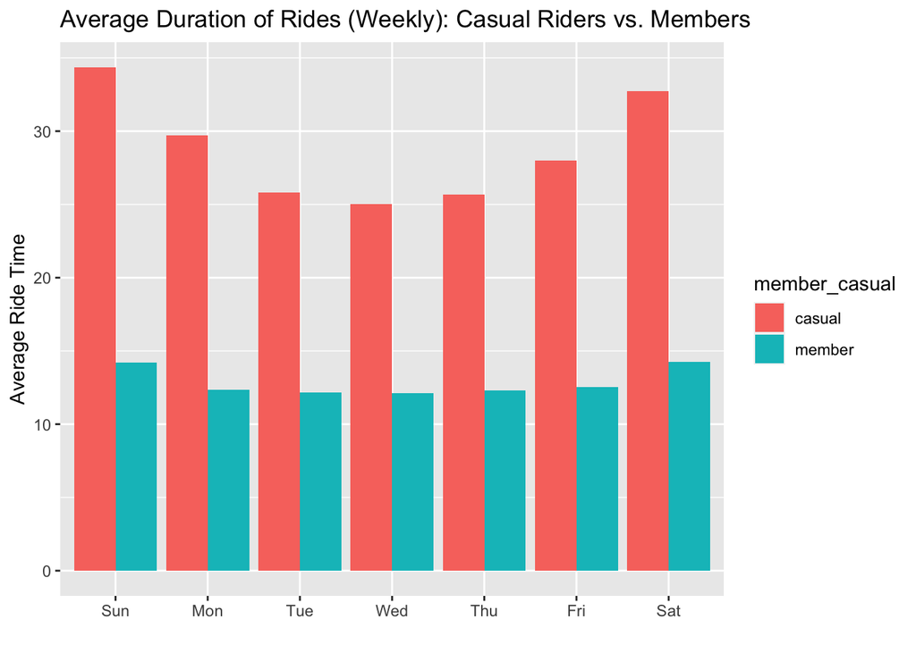

```r
cyclistic_v2 %>%
  mutate(weekday = wday(started_at, label = TRUE)) %>%
  group_by(member_casual, weekday) %>%
  summarize(number_of_rides = n(), average_duration = mean(ride_time)) %>%
  arrange(member_casual, weekday) %>%
  ggplot(aes(x = weekday, y = average_duration, fill = member_casual)) +
  geom_col(position = "dodge") +
  ggtitle("Average Duration of Rides (Weekly): Casual Riders vs. Members") +
  xlab("") +
  ylab("Average Ride Time")
```

**Step #5** Create a visualization for the total number of rides per weekday.

- *Insight:* Members complete a greater number of rides from Monday through Friday.
  - Casual riders who are consistent users during the workweek may be open to considering membership, as the members are much higher users during the workweek.

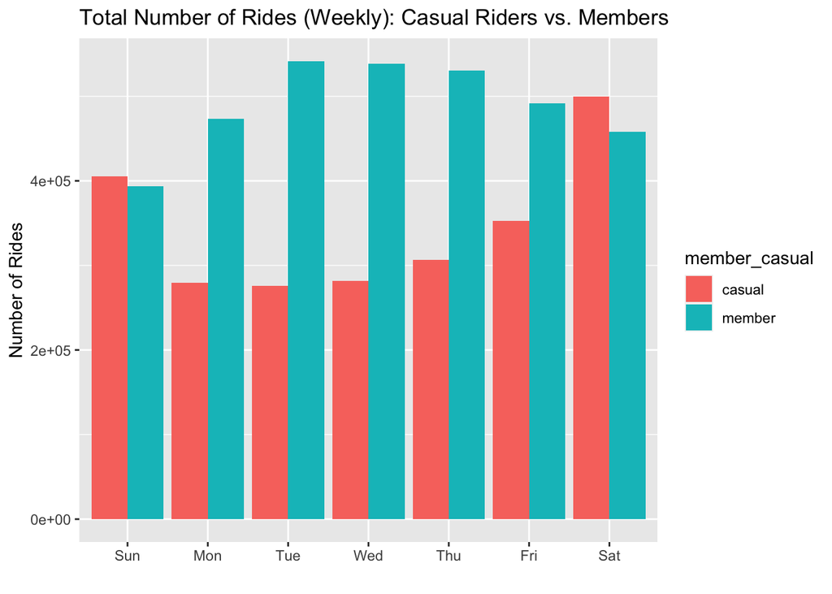

```r
cyclistic_v2 %>%
  mutate(weekday = wday(started_at, label = TRUE)) %>%
  group_by(member_casual, weekday) %>%
  summarize(number_of_rides = n(), average_duration = mean(ride_time)) %>%
  arrange(member_casual, weekday) %>%
  ggplot(aes(x = weekday, y = number_of_rides, fill = member_casual)) +
  geom_col(position = "dodge") +
  ggtitle("Total Number of Rides (Weekly): Casual Riders vs. Members") +
  xlab("") +
  ylab("Number of Rides")
```

**Step #6:** Find the total number of times the ‘classic’ style of bikes are used throughout the week.

- *Insight:* Members are greater users of ‘classic’ bikes throughout the work week. Whereas, casual riders have higher ‘classic’ usage on the weekends.

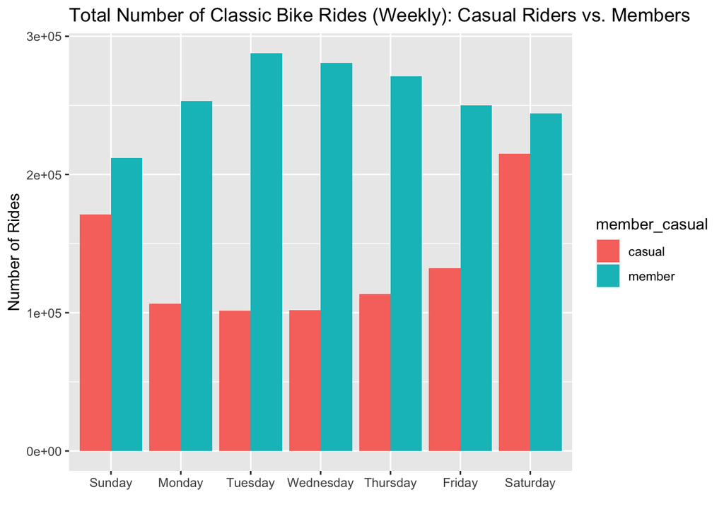

```r
cyclistic_v2 %>%
  filter(rideable_type == "classic_bike") %>%
  group_by(member_casual, day_of_week) %>%
  summarise(number_of_rides = n(), average_duration = mean(ride_time)) %>%
  arrange(member_casual, day_of_week) %>%
  ggplot(aes(x = day_of_week, y = number_of_rides  , fill = member_casual)) +
  geom_col(position = "dodge") +
  ggtitle("Total Number of Classic Bike Rides (Weekly): Casual Riders vs. Members") +
  xlab("") +
  ylab("Number of Rides")
```

**Step #7:** Find the total number of times the ‘electric’ style of bikes are used throughout the week.

- *Insight:* While the data for the ‘electric’ style of bikes is consistent with what was seen with ‘classic’ bikes, the gap between customer groups is more narrow with the ‘electric’ bikes.

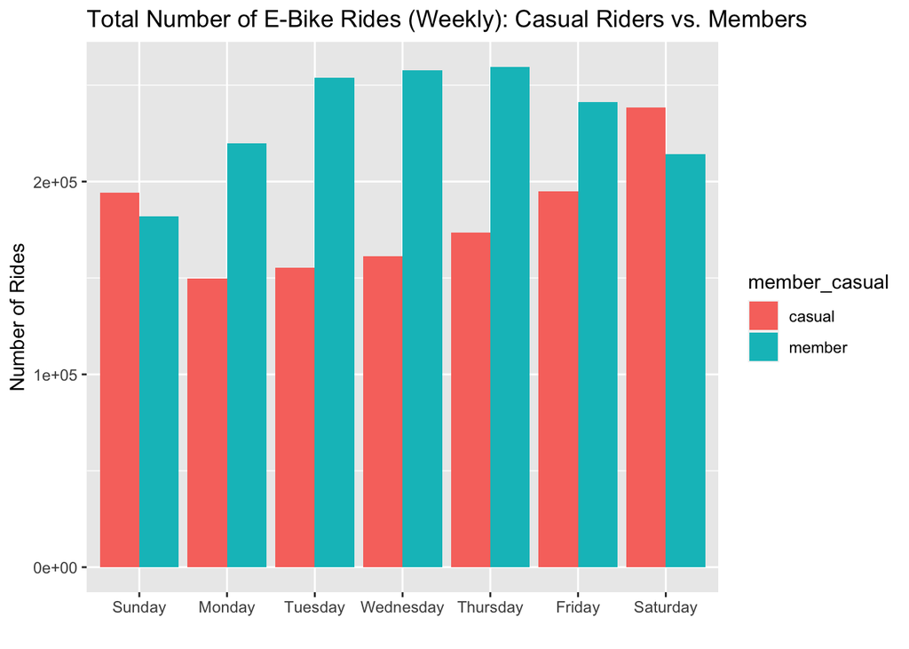

```r
cyclistic_v2 %>%
  filter(rideable_type == "electric_bike") %>%
  group_by(member_casual, day_of_week) %>%
  summarise(number_of_rides = n(), average_duration = mean(ride_time)) %>%
  arrange(member_casual, day_of_week) %>%
  ggplot(aes(x = day_of_week, y = number_of_rides  , fill = member_casual)) +
  geom_col(position = "dodge") +
  ggtitle("Total Number of E-Bike Rides (Weekly): Casual Riders vs. Members") +
  xlab("") +
  ylab("Number of Rides")
```

**Step #8:** Create a visualization for the average duration of rides by month.

- Note: This data set is the trailing twelve months, beginning in October, 2021, and ending in September, 2022. Therefore, the months have been re-ordered to match the time frame.
- *Insight:* Casual riders consistently take longer rides throughout the year, with peaks in October, January, March, and June.

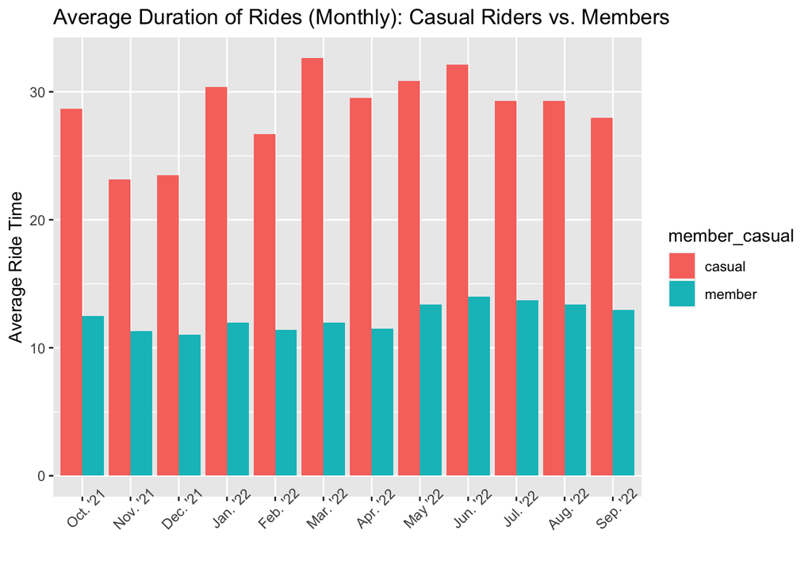

```r
cyclistic_v2$month <- ordered(cyclistic_v2$month, levels = c("10", "11", "12",
                              "01", "02", "03", "04", "05", "06", "07", "08",
                              "09"))
cyclistic_v2$month <- recode(cyclistic_v2$month, "10" = "Oct. '21", "11" =
                           "Nov. '21", "12" = "Dec. '21", "01" = "Jan. '22",
                            "02" = "Feb. '22", "03" = "Mar. '22", "04" =
                              "Apr. '22", "05" = "May '22", "06" = "Jun. '22",
                            "07" = "Jul. '22", "08" = "Aug. '22", "09" =
                              "Sep. '22")

cyclistic_v2 %>%
  group_by(member_casual, month) %>%
  summarise(number_of_rides = n(), average_duration = mean(ride_time)) %>%
  arrange(member_casual, month) %>%
  ggplot(aes(x = month, y = average_duration, fill = member_casual)) +
  geom_col(position = "dodge") +
  theme(axis.text.x = element_text(angle = 45)) +
  ggtitle("Average Duration of Rides (Monthly): Casual Riders vs. Members") +
  xlab("") +
  ylab("Average Ride Time")
```

**Step #9:** Create a visualization for the total number of rides per month.

- *Insight:* While overall ridership begins to rise in Spring, the ridership data for both categories of users is similar at the peak in July.
  - This would be an ideal time for a digital media campaign while ridership is at its highest level and visibility of bikes throughout the city is maximized.

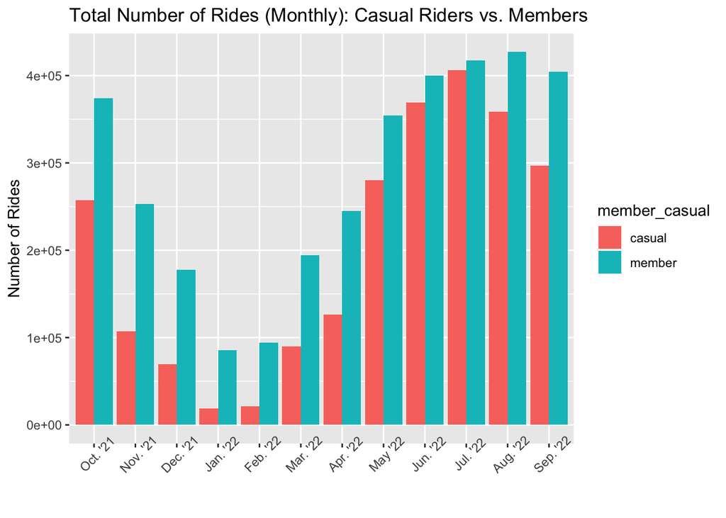

```r
cyclistic_v2 %>%
  group_by(member_casual, month) %>%
  summarise(number_of_rides = n(), average_duration = mean(ride_time)) %>%
  arrange(member_casual, month) %>%
  ggplot(aes(x = month, y = number_of_rides, fill = member_casual)) +
  geom_col(position = "dodge") +
  theme(axis.text.x = element_text(angle = 45)) +
  ggtitle("Total Number of Rides (Monthly): Casual Riders vs. Members") +
  xlab("") +
  ylab("Number of Rides")
```

**Step #10:** Create a visualization for the average duration of rides per month.

- *Insight:* It makes sense that the duration of ‘classic’ rides is longer than the duration of ‘electric’ rides, as E-Bikes are probably quicker.

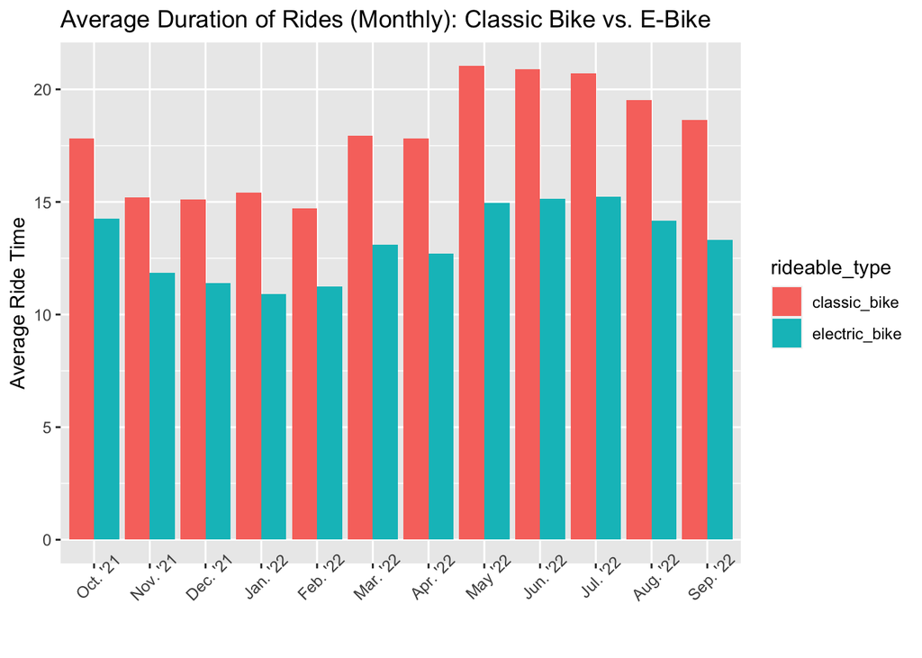

```r
cyclistic_v2 %>%
  filter(rideable_type != "docked_bike") %>%
  group_by(rideable_type, month) %>%
  summarise(number_of_rides = n(), average_duration = mean(ride_time)) %>%
  arrange(rideable_type, month) %>%
  ggplot(aes(x = month, y = average_duration, fill = rideable_type)) +
  geom_col(position = "dodge") +
  theme(axis.text.x = element_text(angle = 45)) +
  ggtitle("Average Duration of Rides (Monthly): Classic Bike vs. E-Bike") +
  xlab("") +
  ylab("Average Ride Time")
```

**Step #11:**Create a visualization for the total number of rides per month; classic bikes vs. electric bikes.

- *Insight:* While classic bikes are more popular in late Spring, the popularity of ‘electric’ bikes is highest in late Summer and early Fall.

[figure not shown]

```r
cyclistic_v2 %>%
  filter(rideable_type != "docked_bike") %>%
  group_by(rideable_type, month) %>%
  summarise(number_of_rides = n(), average_duration = mean(ride_time)) %>%
  arrange(rideable_type, month) %>%
  ggplot(aes(x = month, y = number_of_rides  , fill = rideable_type)) +
  geom_col(position = "dodge") +
  theme(axis.text.x = element_text(angle = 45)) +
  ggtitle("Total Number of Rides (Monthly): Casual Riders vs. Members") +
  xlab("") +
  ylab("Number of Rides")
```

**Step #12:** Create a visualization for the total number rides for the ‘classic’ style of bike, per month.

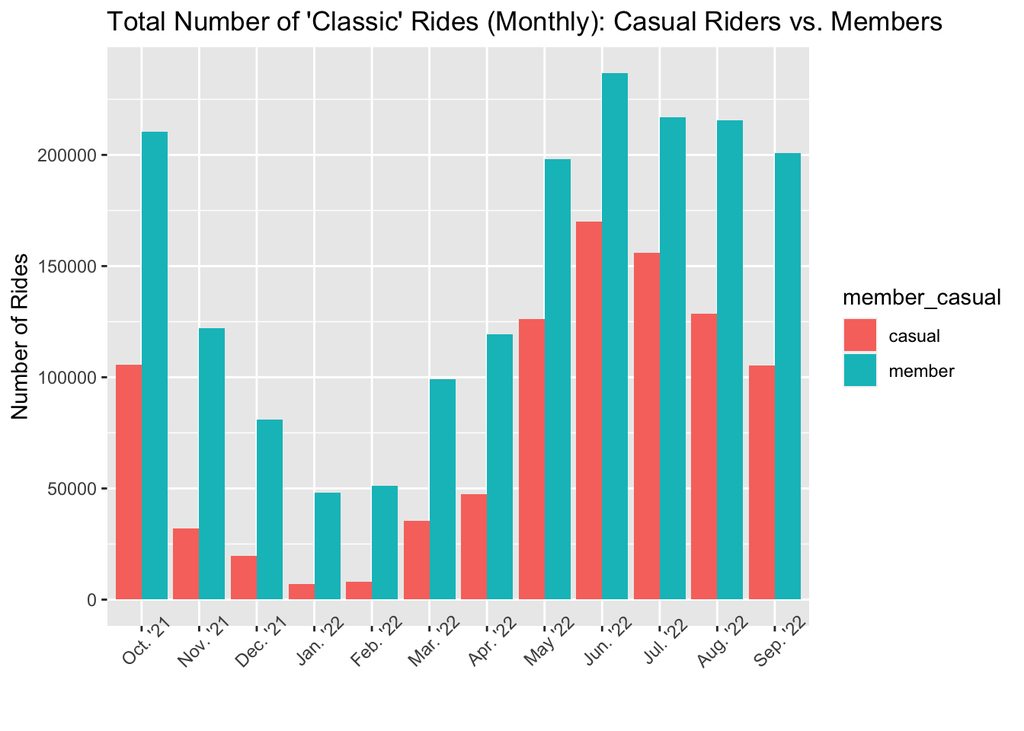

```r
cyclistic_v2 %>%
  filter(rideable_type == "classic_bike") %>%
  group_by(member_casual, month) %>%
  summarise(number_of_rides = n(), average_duration = mean(ride_time)) %>%
  arrange(member_casual, month) %>%
  ggplot(aes(x = month, y = number_of_rides  , fill = member_casual)) +
  geom_col(position = "dodge") +
  theme(axis.text.x = element_text(angle = 45)) +
  ggtitle("Total Number of 'Classic' Rides (Monthly): Casual Riders vs. Members") +
  xlab("") +
  ylab("Number of Rides")
```

**Step #13:** Create a visualization for the total number rides for the ‘electric’ style of bike, per month.

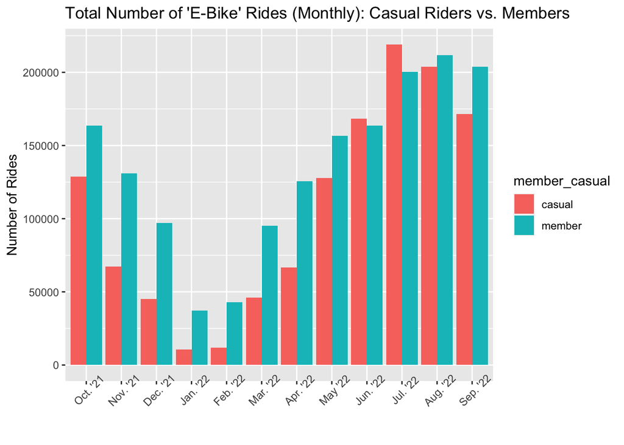

```r
cyclistic_v2 %>%
  filter(rideable_type == "electric_bike") %>%
  group_by(member_casual, month) %>%
  summarise(number_of_rides = n(), average_duration = mean(ride_time)) %>%
  arrange(member_casual, month) %>%
  ggplot(aes(x = month, y = number_of_rides  , fill = member_casual)) +
  geom_col(position = "dodge") +
  theme(axis.text.x = element_text(angle = 45)) +
  ggtitle("Total Number of 'E-Bike' Rides (Monthly): Casual Riders vs. Members") +
  xlab("") +
  ylab("Number of Rides")
```

**Step #14** Isolate data for export to Tableau.

- Weekly ride data.

```r
weekly_ride_data <- cyclistic_v2 %>%
  mutate(weekday = wday(started_at, label = TRUE)) %>%
  group_by(member_casual, weekday) %>%
  summarize(number_of_rides = n(), average_duration = mean(ride_time)) %>%
  arrange(member_casual, weekday)
write.csv(weekly_ride_data, file = "csv_data/weekly_ride_data.csv")
```

- Monthly ride data.

```r
monthly_ride_data <- cyclistic_v2 %>%
  group_by(member_casual, month) %>%
  summarise(number_of_rides = n(), average_duration = mean(ride_time)) %>%
  arrange(member_casual, month)
write.csv(monthly_ride_data, file = "csv_data/monthly_ride_data.csv")
```

- Geo-location data.

```r
casual_geo_data <- cyclistic_v2 %>%
  filter(member_casual == "casual") %>%
  filter(month == "Jun. '22")
casual_geo_data <- casual_geo_data %>%
  select(c(start_lat, start_lng))
str(casual_geo_data)
```

```
## 'data.frame':    369044 obs. of  2 variables:
##  $ start_lat: num  41.9 41.9 41.9 41.8 41.9 ...
##  $ start_lng: num  -87.6 -87.6 -87.7 -87.7 -87.6 ...
```

```r
member_geo_data <- cyclistic_v2 %>%
  filter(member_casual == "member") %>%
  filter(month == "Jun. '22")
member_geo_data <- member_geo_data %>%
  select(c(start_lat, start_lng))
str(member_geo_data)
```

```
## 'data.frame':    400148 obs. of  2 variables:
##  $ start_lat: num  41.9 41.9 41.9 41.9 41.9 ...
##  $ start_lng: num  -87.7 -87.7 -87.7 -87.7 -87.7 ...
```

```r
# Export both sets of data for use in Tableau
write.csv(casual_geo_data, file = "csv_data/casual_start_loc.csv")
write.csv(member_geo_data, file = "csv_data/member_start_loc.csv")
```